# Cell Type Annotation

## Introduction

This is a brief tutorial on automatic cell type annotation of single-cell RNA sequencing (scRNA-seq) data. The primary dataset used here contains hematopoietic and stromal bone marrow populations ([Baccin et al.](https://doi.org/10.1038/s41556-019-0439-6)). The version used here is a subset of the original dataset to have more similar population sizes and speed up processing.

## Load data

This tutorial includes some Bioconductor dependencies. Before proceeding, confirm that Bioconductor is installed and its version is at least 3.10.

```r
if (!requireNamespace("BiocManager", quietly = TRUE)) {
  install.packages("BiocManager")
}
BiocManager::version()
```

```
[1] ‘3.11’
```

If this is not the case, remove all versions of BiocVersion with `remove.packages("BiocVersion")`. Then update Bioconductor packages using `BiocManager::install()`.

Since we are using a Seurat object, load Seurat and related packages.

```r
library(Seurat)
library(ggplot2)
library(cowplot)
library(ggsci)
library(dplyr)
library(stringr)
```

Load the dataset.

```r
so = readRDS(url("https://osf.io/cvnqb/download"))
so
```

```
An object of class Seurat
16701 features across 2821 samples within 1 assay
Active assay: RNA (16701 features, 2872 variable features)
 3 dimensional reductions calculated: pca, tsne, umap
```

Check the experiment labels overlaid onto the UMAP visualization.

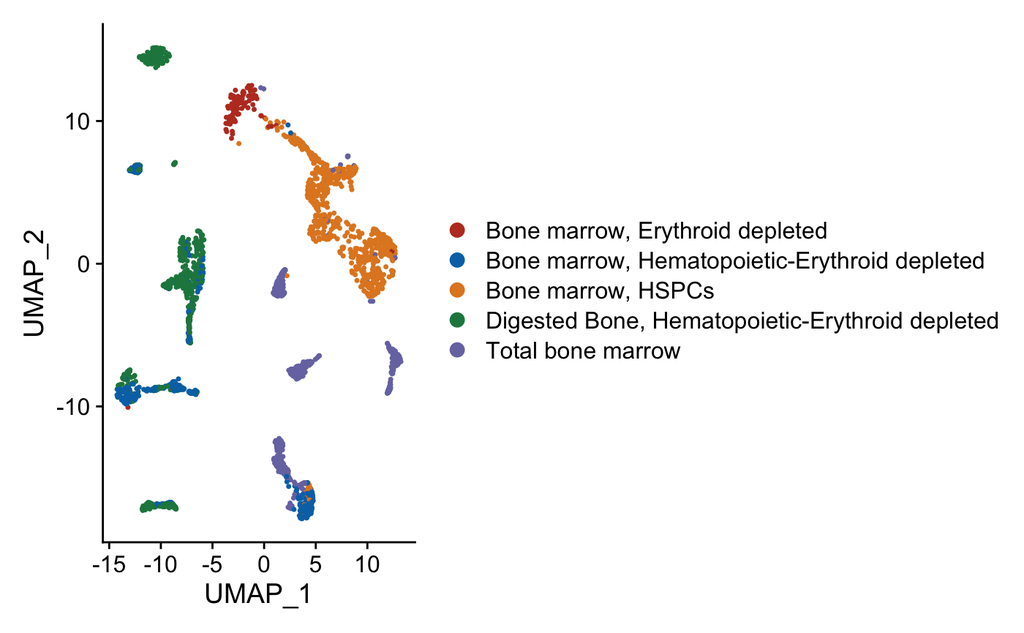

```r
DimPlot(so, reduction = "umap", group.by = "experiment", cells = sample(colnames(so))) +
  scale_color_nejm()
```

Check the experiment labels overlaid onto the tSNE visualization, as shown in the original publication ([original figure](https://www.nature.com/articles/s41556-019-0439-6/figures/1)).

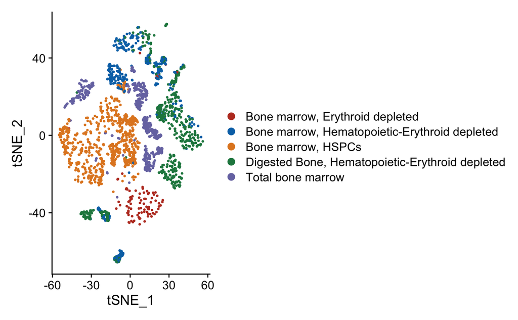

```r
DimPlot(so, reduction = "tsne", group.by = "experiment", cells = sample(colnames(so))) +
  scale_color_nejm()
```

Check the cell type labels overlaid onto the tSNE visualization.

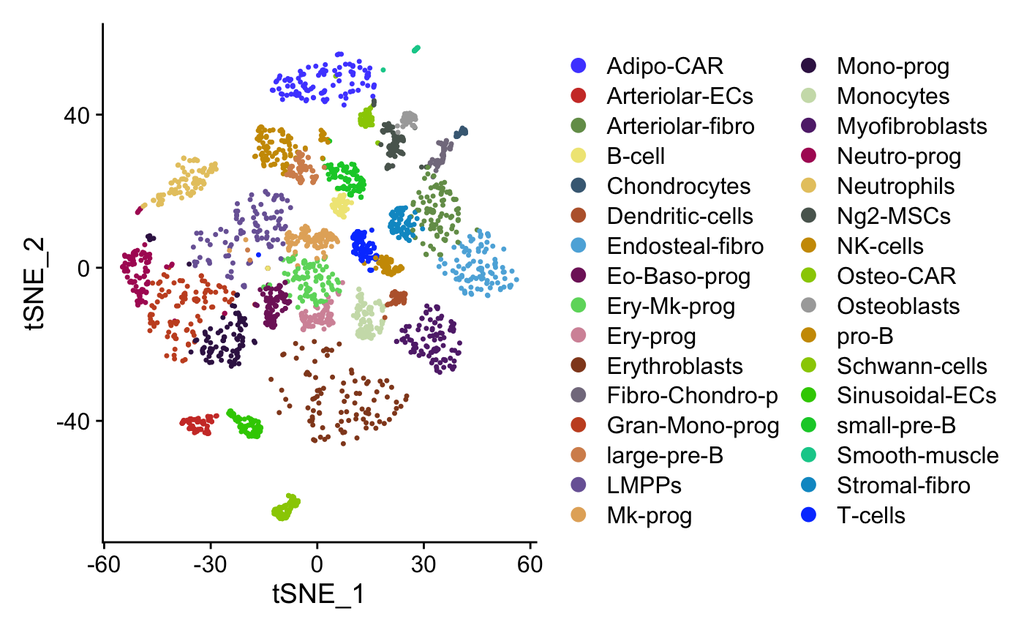

```r
DimPlot(so, reduction = "tsne", group.by = "celltype", cells = sample(colnames(so))) +
  scale_color_igv()
```

## Annotation using SingleR

Load SingleR (install with `BiocManager::install("SingleR")`).

```r
library(SingleR)
```

SingleR expects the input as a matrix or a SummarizedExperiment object.

```r
exp_mat = GetAssayData(so, assay = "RNA", slot = "data")
exp_mat = as.matrix(exp_mat)
dim(exp_mat)
```

```
[1] 16701  2821
```

### MouseRNAseqData cell types

The SingleR package provides normalized expression values and cell types labels based on bulk RNA-seq, microarray, and single-cell RNA-seq data from several different datasets. See the [SingleR vignette](https://bioconductor.org/packages/3.10/bioc/vignettes/SingleR/inst/doc/SingleR.html#5_available_references) for the description.

We will try the mouse dataset from 358 bulk RNA-seq samples of sorted cell populations as the reference. It provides normalized expression values for samples that have been assigned to one of 18 main cell types and 28 subtypes.

```r
singler_se
```

```
class: SummarizedExperiment
dim: 21214 358
metadata(0):
assays(1): logcounts
rownames(21214): Xkr4 Rp1 ... LOC100039574 LOC100039753
rowData names(0):
colnames(358): ERR525589Aligned ERR525592Aligned ... SRR1044043Aligned
  SRR1044044Aligned
colData names(3): label.main label.fine label.ont
```

Restrict to common genes between the test and reference datasets.

```r
common_genes = intersect(rownames(exp_mat), rownames(singler_se))
common_genes = sort(common_genes)
exp_common_mat = exp_mat[common_genes, ]
singler_se = singler_se[common_genes, ]
length(common_genes)
```

```
[1] 13929
```

Perform SingleR annotation.

```r
singler_pred = SingleR(
  test = exp_common_mat,
  ref = singler_se,
  labels = singler_se$label.main
)
```

Each row of the output data frame contains prediction results for a single cell.

```r
head(as.data.frame(singler_pred))
```

|  | scores.Adipocytes | scores.Astrocytes | scores.B.cells | scores.Cardiomyocytes | scores.Dendritic.cells | scores.Endothelial.cells | scores.Epithelial.cells | scores.Erythrocytes | scores.Fibroblasts | scores.Granulocytes | scores.Hepatocytes | scores.Macrophages | scores.Microglia | scores.Monocytes | scores.Neurons | scores.NK.cells | scores.Oligodendrocytes | scores.T.cells | first.labels | tuning.scores.first | tuning.scores.second | labels | pruned.labels |
| --- | --- | --- | --- | --- | --- | --- | --- | --- | --- | --- | --- | --- | --- | --- | --- | --- | --- | --- | --- | --- | --- | --- | --- |
| 2018_2_HSPC_AAACCTGCACAGAGGT | 0.1905645 | 0.08155300 | 0.3721424 | 0.1428444 | 0.4028147 | 0.2003283 | 0.1833415 | 0.3975358 | 0.1666118 | 0.4369015 | 0.2194820 | 0.3734197 | 0.3270500 | 0.4471765 | 0.1604562 | 0.3427353 | 0.1516657 | 0.3559239 | Monocytes | 0.2872241 | 0.139217260 | Granulocytes | Granulocytes |
| 2018_2_HSPC_AAACCTGGTCCATGAT | 0.1985291 | 0.13961574 | 0.3115408 | 0.1837632 | 0.2794788 | 0.2454377 | 0.2118632 | 0.3218364 | 0.2037228 | 0.2822915 | 0.2106154 | 0.2879146 | 0.2545115 | 0.3116681 | 0.2008875 | 0.3020594 | 0.1864166 | 0.3162480 | Erythrocytes | 0.1808202 | -0.064900691 | Erythrocytes | Erythrocytes |
| 2018_2_HSPC_AAACGGGCAATCCGAT | 0.1841531 | 0.09248048 | 0.3577884 | 0.1668537 | 0.3137731 | 0.2506204 | 0.1805830 | 0.3529691 | 0.1891210 | 0.3142322 | 0.2171904 | 0.2809236 | 0.2501324 | 0.3427300 | 0.1699574 | 0.3133357 | 0.1348589 | 0.3378814 | B cells | 0.2008930 | 0.115814931 | Erythrocytes | Erythrocytes |
| 2018_2_HSPC_AAACGGGTCAAACGGG | 0.2092590 | 0.10737862 | 0.3710029 | 0.1753280 | 0.3518687 | 0.2393265 | 0.1985754 | 0.3694079 | 0.2040401 | 0.3702608 | 0.2245612 | 0.3531264 | 0.3081372 | 0.4010737 | 0.1874019 | 0.3466992 | 0.1563129 | 0.3664447 | Monocytes | 0.3331101 | 0.005219128 | Monocytes | Monocytes |
| 2018_2_HSPC_AAACGGGTCGGCATCG | 0.2173679 | 0.14057400 | 0.3548307 | 0.1938828 | 0.3187886 | 0.2505686 | 0.2231355 | 0.3806398 | 0.2206236 | 0.3266455 | 0.2292579 | 0.3206287 | 0.3019269 | 0.3567329 | 0.2294447 | 0.3350522 | 0.1904750 | 0.3516363 | Erythrocytes | 0.2301583 | 0.082471546 | Erythrocytes | Erythrocytes |
| 2018_2_HSPC_AAAGATGAGAGGACGG | 0.1907470 | 0.10471800 | 0.3238499 | 0.1543175 | 0.3224362 | 0.2213879 | 0.1861938 | 0.3331576 | 0.2094144 | 0.3256562 | 0.1938875 | 0.3080861 | 0.2763785 | 0.3532303 | 0.1903613 | 0.3160643 | 0.1644837 | 0.3224082 | Monocytes | 0.4197849 | 0.203799705 | Monocytes | Monocytes |

Add the assigned labels to the Seurat object.

```r
so_labeled = AddMetaData(so, as.data.frame(singler_pred))
```

Check the assigned labels to the original labels.

```r
so_labeled@meta.data %>% select(labels) %>% table(useNA = "ifany")
```

```
.
       Adipocytes           B cells    Cardiomyocytes   Dendritic cells Endothelial cells
                6               400                 3                 1               201
     Erythrocytes       Fibroblasts      Granulocytes       Macrophages         Monocytes
              372               815               191                 2               534
         NK cells  Oligodendrocytes           T cells
               72                90               134
```

SingleR also attempts to remove low quality or ambiguous assignments. Ambiguous assignments are based on the difference between the score for the assigned label and the median across all labels for each cell. Tuning parameters can be adjusted with `pruneScores()`. We can check how many cells are considered ambiguous and which populations they potentially belong to.

```r
so_labeled@meta.data %>% select(pruned.labels) %>% table(useNA = "ifany")
```

```
.
       Adipocytes           B cells    Cardiomyocytes   Dendritic cells Endothelial cells
                6               400                 3                 1               197
     Erythrocytes       Fibroblasts      Granulocytes       Macrophages         Monocytes
              372               815               191                 2               534
         NK cells  Oligodendrocytes           T cells              <NA>
               66                88               115                31
```

Visualize MouseRNAseqData cell type labels.

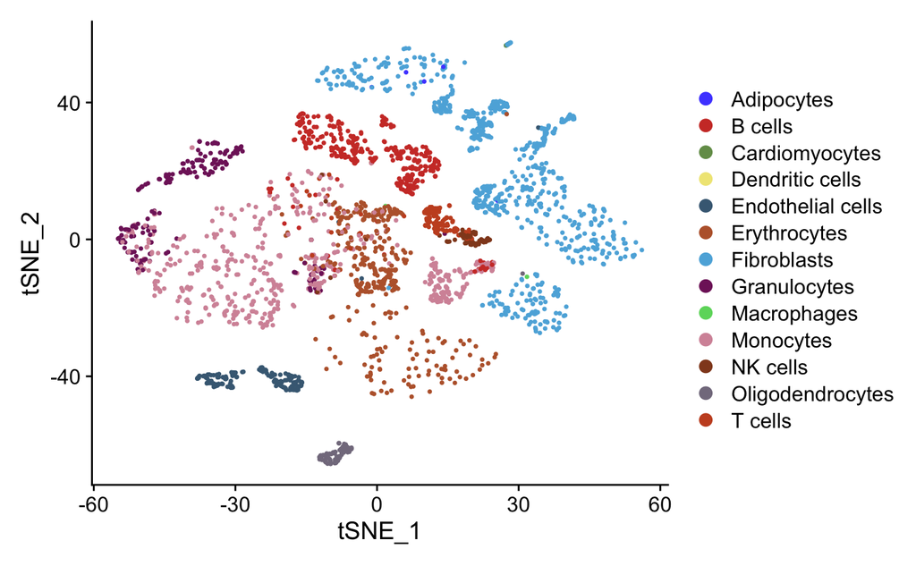

```r
DimPlot(so_labeled, reduction = "tsne", group.by = "labels") +
  scale_color_igv()
```

## Annotation using clustermole

SingleR is able to label cells, but it requires a reference dataset.

A more exploratory and unbiased approach is possible with clustermole, an R package that provides a collection of cell type markers for thousands of human and mouse cell populations sourced from a variety of databases as well as methods to query them.

Load clustermole.

```r
library(clustermole)
```

### Available cell types

We can retrieve a list of all markers in the clustermole database to see all the available options. Each row in the returned data frame is a combination of each cell type and its genes.

```r
markers_tbl = clustermole_markers()
head(markers_tbl)
```

| db | species | organ | celltype | celltype_full | n_genes | gene_original | gene |
| --- | --- | --- | --- | --- | --- | --- | --- |
| CellMarker | Human | Embryo | 1-cell stage cell (Blastomere) | 1-cell stage cell (Blastomere) \| Embryo \| Human \| CellMarker | 45 | ACCSL | ACCSL |
| CellMarker | Human | Embryo | 1-cell stage cell (Blastomere) | 1-cell stage cell (Blastomere) \| Embryo \| Human \| CellMarker | 45 | ACVR1B | ACVR1B |
| CellMarker | Human | Embryo | 1-cell stage cell (Blastomere) | 1-cell stage cell (Blastomere) \| Embryo \| Human \| CellMarker | 45 | ARHGEF16 | ARHGEF16 |
| CellMarker | Human | Embryo | 1-cell stage cell (Blastomere) | 1-cell stage cell (Blastomere) \| Embryo \| Human \| CellMarker | 45 | ASF1B | ASF1B |
| CellMarker | Human | Embryo | 1-cell stage cell (Blastomere) | 1-cell stage cell (Blastomere) \| Embryo \| Human \| CellMarker | 45 | BCL2L10 | BCL2L10 |
| CellMarker | Human | Embryo | 1-cell stage cell (Blastomere) | 1-cell stage cell (Blastomere) \| Embryo \| Human \| CellMarker | 45 | BLCAP | BLCAP |

Check the available cell types (ignore gene columns).

```r
markers_tbl %>% distinct(celltype, organ, db)
```

| db | organ | celltype |
| --- | --- | --- |
| CellMarker | Embryo | 1-cell stage cell (Blastomere) |
| SaVanT |  | 3T3-L1 |
| CellMarker | Embryo | 4-cell stage cell (Blastomere) |
| CellMarker | Embryo | 8-cell stage cell (Blastomere) |
| SaVanT |  | ACD |
| CellMarker | Pancreatic islet | Acinar cell |
| PanglaoDB | Pancreas | Acinar cells |
| SaVanT |  | ACN |
| CellMarker | Blood | Activated CD4+ T cell |
| CellMarker | Blood | Activated CD8+ T cell |

[output cut: 990 more lines]

### Marker gene overlaps

Calculate the average expression levels for the clusters for enrichment analysis using Seurat’s `AverageExpression` function, convert to a matrix, and log-transform.

```r
Idents(so) = "celltype"
avg_exp_mat = AverageExpression(so, assays = "RNA", slot = "data")
```

[output not shown]

```r
avg_exp_mat = as.matrix(avg_exp_mat$RNA)
avg_exp_mat = log1p(avg_exp_mat)
```

Check the average expression matrix.

```r
avg_exp_mat[1:5, 1:5]
```

```
        Adipo-CAR Arteriolar-ECs Arteriolar-fibro    B-cell Chondrocytes
Sox17   0.0000000      2.5800606        0.0000000 0.0000000   0.00000000
Mrpl15  0.4315376      0.5284282        0.3304569 0.8481054   0.07307574
Lypla1  0.1990537      0.4477973        0.2448583 0.6352917   0.09397463
Gm37988 0.0000000      0.0000000        0.0000000 0.0000000   0.00000000
Tcea1   0.5620502      0.7077588        0.6135480 0.7798060   0.52126901
```

Check the cell type names.

```r
levels(Idents(so))
```

```
 [1] "Adipo-CAR"        "Arteriolar-ECs"   "Arteriolar-fibro" "B-cell"
 [5] "Chondrocytes"     "Dendritic-cells"  "Endosteal-fibro"  "Eo-Baso-prog"
 [9] "Ery-Mk-prog"      "Ery-prog"         "Erythroblasts"    "Fibro-Chondro-p"
[13] "Gran-Mono-prog"   "large-pre-B"      "LMPPs"            "Mk-prog"
[17] "Mono-prog"        "Monocytes"        "Myofibroblasts"   "Neutro-prog"
[21] "Neutrophils"      "Ng2-MSCs"         "NK-cells"         "Osteo-CAR"
[25] "Osteoblasts"      "pro-B"            "Schwann-cells"    "Sinusoidal-ECs"
[29] "small-pre-B"      "Smooth-muscle"    "Stromal-fibro"    "T-cells"
```

Find markers for the B-cell cluster.

```r
b_genes = rownames(avg_exp_mat[avg_exp_mat[, "B-cell"] == rowMaxs(avg_exp_mat), ])
length(b_genes)
```

```
[1] 517
```

```r
b_markers_df = FindMarkers(so, ident.1 = "B-cell", features = b_genes, verbose = FALSE)
```

```r
nrow(b_markers_df)
```

```
[1] 165
```

Check the markers table.

```r
head(b_markers_df)
```

|  | p_val | avg_logFC | pct.1 | pct.2 | p_val_adj |
| --- | --- | --- | --- | --- | --- |
| Ms4a1 | 5.812353e-264 | 2.6941262 | 0.900 | 0.030 | 9.707210e-260 |
| Fcmr | 2.539032e-196 | 1.8946222 | 0.762 | 0.031 | 4.240437e-192 |
| Cd74 | 5.821464e-177 | 3.6878990 | 0.863 | 0.051 | 9.722428e-173 |
| Ly6d | 1.245230e-160 | 2.7417295 | 0.912 | 0.066 | 2.079658e-156 |
| Gm43603 | 4.415715e-148 | 0.9206677 | 0.338 | 0.004 | 7.374686e-144 |
| Bank1 | 1.688883e-130 | 1.0720138 | 0.500 | 0.019 | 2.820604e-126 |

With the default cutoffs, this gives us a data frame with hundreds of genes. Let’s subset to just the top 20 genes.

```r
b_markers = rownames(b_markers_df)
b_markers = head(b_markers, 20)
b_markers
```

```
 [1] "Ms4a1"         "Fcmr"          "Cd74"          "Ly6d"          "Gm43603"
 [6] "Bank1"         "2010309G21Rik" "Fcer2a"        "H2-DMb2"       "H2-Eb1"
[11] "Cd79a"         "H2-Aa"         "Tnfrsf13c"     "Ltb"           "Cd79b"
[16] "Ccr7"          "Fcrl1"         "Siglecg"       "Cd83"          "Srpk3"
```

Check overlap of our B-cell markers with all cell type signatures.

```r
overlaps_tbl = clustermole_overlaps(genes = b_markers, species = "mm")
```

Check the top scoring cell types for the B-cell cluster.

```r
head(overlaps_tbl, 10)
```

| db | species | organ | celltype | celltype_full | n_genes | overlap | p_value | fdr |
| --- | --- | --- | --- | --- | --- | --- | --- | --- |
| SaVanT |  |  | follicular_B-cells | follicular_B-cells \| SaVanT | 50 | 12 | 1.945413e-27 | 4.986094e-24 |
| CellMarker | Human | Kidney | B cell (Renal Cell Carcinoma) | B cell (Renal Cell Carcinoma) \| Kidney \| Human \| CellMarker | 222 | 15 | 3.084262e-26 | 3.952481e-23 |
| PanglaoDB | Human | Immune system | B cells | B cells \| Immune system \| Human \| PanglaoDB | 96 | 12 | 1.124832e-23 | 9.609812e-21 |
| SCSig | Human | Digestive System | Aizarani_Liver_C34_MHC_II_pos_B_cells | Aizarani_Liver_C34_MHC_II_pos_B_cells \| Digestive System \| Human \| SCSig | 127 | 12 | 3.359441e-22 | 2.152562e-19 |
| SaVanT | Mouse |  | IMGN_B_Fo_MLN | IMGN_B_Fo_MLN \| Mouse \| SaVanT | 50 | 10 | 8.364017e-22 | 3.572829e-19 |
| SaVanT |  |  | lymph_nodes | lymph_nodes \| SaVanT | 50 | 10 | 8.364017e-22 | 3.572829e-19 |
| SCSig | Human | Central Nervous System | Fan_Embryonic_CTX_Brain_B_cell | Fan_Embryonic_CTX_Brain_B_cell \| Central Nervous System \| Human \| SCSig | 94 | 11 | 6.744611e-21 | 2.469491e-18 |
| CellMarker | Human | Kidney | B cell | B cell \| Kidney \| Human \| CellMarker | 585 | 15 | 8.112500e-20 | 2.599042e-17 |
| SaVanT | Mouse |  | IMGN_B_Fo_LN | IMGN_B_Fo_LN \| Mouse \| SaVanT | 50 | 9 | 3.823607e-19 | 6.533271e-17 |
| SaVanT | Mouse |  | IMGN_B_FrE_BM | IMGN_B_FrE_BM \| Mouse \| SaVanT | 50 | 9 | 3.823607e-19 | 6.533271e-17 |

Find markers for the Adipo-CAR cluster.

```r
acar_genes = rownames(avg_exp_mat[avg_exp_mat[, "Adipo-CAR"] == rowMaxs(avg_exp_mat), ])
length(acar_genes)
```

```
[1] 888
```

```r
acar_markers_df = FindMarkers(so, ident.1 = "Adipo-CAR", features = acar_genes, verbose = FALSE)
```

```r
nrow(acar_markers_df)
```

```
[1] 326
```

Check the markers table.

```r
head(acar_markers_df)
```

|  | p_val | avg_logFC | pct.1 | pct.2 | p_val_adj |
| --- | --- | --- | --- | --- | --- |
| Adipoq | 0.000000e+00 | 3.379680 | 0.909 | 0.014 | 0.000000e+00 |
| Kng1 | 0.000000e+00 | 2.425311 | 0.828 | 0.018 | 0.000000e+00 |
| Kng2 | 4.648866e-308 | 2.253351 | 0.859 | 0.022 | 7.764071e-304 |
| Esm1 | 1.049337e-289 | 2.625948 | 0.899 | 0.029 | 1.752498e-285 |
| Cxcl12 | 5.330320e-279 | 3.805677 | 1.000 | 0.046 | 8.902168e-275 |
| Lpl | 2.771009e-254 | 3.405121 | 0.980 | 0.053 | 4.627861e-250 |

With the default cutoffs, this gives us a data frame with hundreds of genes. Let’s subset to just the top 20 genes.

```r
acar_markers = rownames(acar_markers_df)
acar_markers = head(acar_markers, 20)
acar_markers
```

```
 [1] "Adipoq"        "Kng1"          "Kng2"          "Esm1"          "Cxcl12"
 [6] "Lpl"           "Gdpd2"         "Agt"           "Dpep1"         "Lepr"
[11] "Fst"           "Chrdl1"        "Pdzrn4"        "Kitl"          "Ccl19"
[16] "Ptx3"          "Ackr4"         "1500009L16Rik" "Gas6"          "Serpina12"
```

Check overlap of our Adipo-CAR markers with all cell type signatures.

```r
overlaps_tbl = clustermole_overlaps(genes = acar_markers, species = "mm")
```

Check the top scoring cell types for the Adipo-CAR cluster.

```r
head(overlaps_tbl, 10)
```

| db | species | organ | celltype | celltype_full | n_genes | overlap | p_value | fdr |
| --- | --- | --- | --- | --- | --- | --- | --- | --- |
| SCSig | Human | Hematopoietic system | Hay_Bone_Marrow_Stromal | Hay_Bone_Marrow_Stromal \| Hematopoietic system \| Human \| SCSig | 1551 | 13 | 5.133396e-10 | 1.315689e-06 |
| SaVanT | Human |  | HBA_Adipocyte | HBA_Adipocyte \| Human \| SaVanT | 50 | 4 | 2.531397e-07 | 2.162657e-04 |
| SaVanT | Mouse |  | IMGN_FRC_SLN | IMGN_FRC_SLN \| Mouse \| SaVanT | 50 | 4 | 2.531397e-07 | 2.162657e-04 |
| PanglaoDB | Mouse | Connective tissue | Adipocytes | Adipocytes \| Connective tissue \| Mouse \| PanglaoDB | 114 | 4 | 7.008487e-06 | 3.982892e-03 |
| PanglaoDB | Human | Connective tissue | Adipocytes | Adipocytes \| Connective tissue \| Human \| PanglaoDB | 117 | 4 | 7.769980e-06 | 3.982892e-03 |
| SaVanT | Human |  | HPCA_Adipocytes | HPCA_Adipocytes \| Human \| SaVanT | 50 | 3 | 2.276141e-05 | 8.333926e-03 |
| SaVanT | Mouse |  | IMGN_FRC_MLN | IMGN_FRC_MLN \| Mouse \| SaVanT | 50 | 3 | 2.276141e-05 | 8.333926e-03 |
| CellMarker | Mouse | Adipose tissue | Schwalie et al.Nature.P3 | Schwalie et al.Nature.P3 \| Adipose tissue \| Mouse \| CellMarker | 193 | 4 | 6.771142e-05 | 2.169304e-02 |
| CellMarker | Mouse | Adipose tissue | Schwalie et al.Nature.G3 | Schwalie et al.Nature.G3 \| Adipose tissue \| Mouse \| CellMarker | 191 | 4 | 8.461420e-05 | 2.409625e-02 |
| SCSig | Human | Central Nervous System | Manno_Midbrain_Neurotypes_hEndo | Manno_Midbrain_Neurotypes_hEndo \| Central Nervous System \| Human \| SCSig | 864 | 6 | 2.681042e-04 | 6.824274e-02 |

Find markers for the Osteoblasts cluster.

```r
o_genes = rownames(avg_exp_mat[avg_exp_mat[, "Osteoblasts"] == rowMaxs(avg_exp_mat), ])
length(o_genes)
```

```
[1] 390
```

```r
o_markers_df = FindMarkers(so, ident.1 = "Osteoblasts", features = o_genes, verbose = FALSE)
```

```r
nrow(o_markers_df)
```

```
[1] 182
```

Check the markers table.

```r
head(o_markers_df)
```

|  | p_val | avg_logFC | pct.1 | pct.2 | p_val_adj |
| --- | --- | --- | --- | --- | --- |
| Cpz | 9.133423e-296 | 1.437388 | 0.736 | 0.007 | 1.525373e-291 |
| Smpd3 | 8.973995e-279 | 1.329793 | 0.849 | 0.014 | 1.498747e-274 |
| Col22a1 | 2.718722e-278 | 1.157844 | 0.774 | 0.010 | 4.540537e-274 |
| Ifitm5 | 4.123442e-268 | 2.738608 | 0.981 | 0.024 | 6.886561e-264 |
| Mlip | 2.320804e-264 | 0.863705 | 0.566 | 0.003 | 3.875974e-260 |
| Bglap | 1.721920e-256 | 5.482939 | 0.830 | 0.016 | 2.875779e-252 |

With the default cutoffs, this gives us a data frame with hundreds of genes. Let’s subset to just the top 20 genes.

```r
o_markers = rownames(o_markers_df)
o_markers = head(o_markers, 20)
o_markers
```

```
 [1] "Cpz"           "Smpd3"         "Col22a1"       "Ifitm5"        "Mlip"
 [6] "Bglap"         "Lipc"          "Cgref1"        "Col13a1"       "Entpd3"
[11] "Fabp3"         "Bglap2"        "Cthrc1"        "Bglap3"        "Rerg"
[16] "Cdo1"          "Car3"          "RP23-457J22.1" "Col24a1"       "Bmp3"
```

Check overlap of our Osteoblasts markers with all cell type signatures.

```r
overlaps_tbl = clustermole_overlaps(genes = o_markers, species = "mm")
```

Check the top scoring cell types for the Osteoblasts cluster.

```r
head(overlaps_tbl, 10)
```

| db | species | organ | celltype | celltype_full | n_genes | overlap | p_value | fdr |
| --- | --- | --- | --- | --- | --- | --- | --- | --- |
| SCSig | Human | Digestive System | Gao_Large_Intestine_24W_C1_DCLK1pos_Progenitor | Gao_Large_Intestine_24W_C1_DCLK1pos_Progenitor \| Digestive System \| Human \| SCSig | 95 | 3 | 0.0001400386 | 0.1906578 |
| CellMarker | Human | Large intestine | DCLK1+ progenitor cell | DCLK1+ progenitor cell \| Large intestine \| Human \| CellMarker | 97 | 3 | 0.0001487771 | 0.1906578 |
| SaVanT |  |  | adipose_brown | adipose_brown \| SaVanT | 50 | 2 | 0.0012705634 | 0.8141135 |
| SaVanT | Human |  | HPCA_Adipocytes | HPCA_Adipocytes \| Human \| SaVanT | 50 | 2 | 0.0012705634 | 0.8141135 |
| SCSig | Human | Central Nervous System | Manno_Midbrain_Neurotypes_hProgM | Manno_Midbrain_Neurotypes_hProgM \| Central Nervous System \| Human \| SCSig | 296 | 3 | 0.0035937569 | 1.0000000 |
| CellMarker | Mouse | Bone | Osteocyte | Osteocyte \| Bone \| Mouse \| CellMarker | 5 | 1 | 0.0053087829 | 1.0000000 |
| CellMarker | Human | Brain | Lake et al.Science.In7 | Lake et al.Science.In7 \| Brain \| Human \| CellMarker | 6 | 1 | 0.0063673405 | 1.0000000 |
| CellMarker | Mouse | Adipose tissue | Osteogenic cell | Osteogenic cell \| Adipose tissue \| Mouse \| CellMarker | 6 | 1 | 0.0063673405 | 1.0000000 |
| CellMarker | Mouse | Retina | Rheaume et al.Nat Commun.24 | Rheaume et al.Nat Commun.24 \| Retina \| Mouse \| CellMarker | 6 | 1 | 0.0063673405 | 1.0000000 |
| SCSig | Human | Central Nervous System | Manno_Midbrain_Neurotypes_hSert | Manno_Midbrain_Neurotypes_hSert \| Central Nervous System \| Human \| SCSig | 439 | 3 | 0.0105940833 | 1.0000000 |

### Enrichment of markers

Run enrichment of all cell type signatures across all clusters.

```r
enrich_tbl = clustermole_enrichment(expr_mat = avg_exp_mat, species = "mm")
```

```
Some gene sets have size one. Consider setting 'min.sz > 1'.Selecting by score
```

Most enriched cell types for the B-cell cluster.

```r
enrich_tbl %>% filter(cluster == "B-cell") %>% select(-cluster) %>% head(10)
```

| celltype_full | score | db | species | organ | celltype | n_genes |
| --- | --- | --- | --- | --- | --- | --- |
| B cell \| Tonsil \| Human \| CellMarker | 0.9720065 | CellMarker | Human | Tonsil | B cell | 5 |
| naive B-cells_BLUEPRINT_3 \| Human \| xCell | 0.9510557 | xCell | Human |  | naive B-cells_BLUEPRINT_3 | 9 |
| naive B-cells_BLUEPRINT_1 \| Human \| xCell | 0.9499869 | xCell | Human |  | naive B-cells_BLUEPRINT_1 | 8 |
| follicular_B-cells \| SaVanT | 0.8912867 | SaVanT |  |  | follicular_B-cells | 50 |
| B-cells_HPCA_3 \| Human \| xCell | 0.8908462 | xCell | Human |  | B-cells_HPCA_3 | 8 |
| B cell \| Lymphoid tissue \| Human \| CellMarker | 0.8796508 | CellMarker | Human | Lymphoid tissue | B cell | 6 |
| B cell (B cell type MALT lymphoma) \| Lymphoid tissue \| Human \| CellMarker | 0.8795979 | CellMarker | Human | Lymphoid tissue | B cell (B cell type MALT lymphoma) | 5 |
| B cell \| Liver \| Human \| CellMarker | 0.8633353 | CellMarker | Human | Liver | B cell | 6 |
| Follicular B cell \| Lymphoid tissue \| Mouse \| CellMarker | 0.8594394 | CellMarker | Mouse | Lymphoid tissue | Follicular B cell | 8 |
| IMGN_B_Fo_MLN \| Mouse \| SaVanT | 0.8496921 | SaVanT | Mouse |  | IMGN_B_Fo_MLN | 50 |

Most enriched cell types for the Adipo-CAR cluster.

```r
enrich_tbl %>% filter(cluster == "Adipo-CAR") %>% select(-cluster) %>% head(10)
```

| celltype_full | score | db | species | organ | celltype | n_genes |
| --- | --- | --- | --- | --- | --- | --- |
| Urothelium cell \| Kidney \| Human \| CellMarker | 0.9827866 | CellMarker | Human | Kidney | Urothelium cell | 6 |
| Spermatogonium \| Testis \| Human \| CellMarker | 0.7504402 | CellMarker | Human | Testis | Spermatogonium | 7 |
| DC_BLUEPRINT_1 \| Human \| xCell | 0.7346672 | xCell | Human |  | DC_BLUEPRINT_1 | 6 |
| Adipogenic cell \| Adipose tissue \| Mouse \| CellMarker | 0.7206373 | CellMarker | Mouse | Adipose tissue | Adipogenic cell | 6 |
| Fan_Embryonic_CTX_IN_2_Interneuron \| Central Nervous System \| Human \| SCSig | 0.7177020 | SCSig | Human | Central Nervous System | Fan_Embryonic_CTX_IN_2_Interneuron | 7 |
| GABAergic neuron \| Human \| CellMarker | 0.7087632 | CellMarker | Human |  | GABAergic neuron | 5 |
| Late neuroblast \| Brain \| Mouse \| CellMarker | 0.7045580 | CellMarker | Mouse | Brain | Late neuroblast | 6 |
| Lake et al.Science.In4 \| Brain \| Human \| CellMarker | 0.6901528 | CellMarker | Human | Brain | Lake et al.Science.In4 | 6 |
| DC_BLUEPRINT_3 \| Human \| xCell | 0.6792120 | xCell | Human |  | DC_BLUEPRINT_3 | 6 |
| Colorectal stem cell \| Colorectum \| Human \| CellMarker | 0.6767875 | CellMarker | Human | Colorectum | Colorectal stem cell | 5 |

Most enriched cell types for the Osteoblasts cluster.

```r
enrich_tbl %>% filter(cluster == "Osteoblasts") %>% select(-cluster) %>% head(10)
```

| celltype_full | score | db | species | organ | celltype | n_genes |
| --- | --- | --- | --- | --- | --- | --- |
| Endocrine cell \| Embryo \| Mouse \| CellMarker | 0.9549804 | CellMarker | Mouse | Embryo | Endocrine cell | 6 |
| Osteocyte \| Bone \| Mouse \| CellMarker | 0.9029015 | CellMarker | Mouse | Bone | Osteocyte | 5 |
| Osteogenic cell \| Adipose tissue \| Mouse \| CellMarker | 0.8756883 | CellMarker | Mouse | Adipose tissue | Osteogenic cell | 6 |
| Activated CD8+ T cell \| Blood \| Mouse \| CellMarker | 0.8179290 | CellMarker | Mouse | Blood | Activated CD8+ T cell | 5 |
| Kidney progenitor cells \| Kidney \| Human \| PanglaoDB | 0.8139752 | PanglaoDB | Human | Kidney | Kidney progenitor cells | 7 |
| Kidney progenitor cells \| Kidney \| Mouse \| PanglaoDB | 0.8139752 | PanglaoDB | Mouse | Kidney | Kidney progenitor cells | 7 |
| Ito cell (hepatic stellate cell) \| Liver \| Human \| CellMarker | 0.8067048 | CellMarker | Human | Liver | Ito cell (hepatic stellate cell) | 6 |
| Rheaume et al.Nat Commun.24 \| Retina \| Mouse \| CellMarker | 0.7586896 | CellMarker | Mouse | Retina | Rheaume et al.Nat Commun.24 | 6 |
| Fan_Embryonic_CTX_IN_5_Interneuron \| Central Nervous System \| Human \| SCSig | 0.7491233 | SCSig | Human | Central Nervous System | Fan_Embryonic_CTX_IN_5_Interneuron | 6 |
| Gao_Large_Intestine_24W_C4_PROM1Low_Progenitor \| Digestive System \| Human \| SCSig | 0.7455772 | SCSig | Human | Digestive System | Gao_Large_Intestine_24W_C4_PROM1Low_Progenitor | 6 |

[previous tutorials](https://igordot.github.io/tutorials/)